# Homework #3

Tyler Smith, smithty27

February 15, 2020

```r
library(reshape2)
tips2 <- tips
?tips
```

```
## starting httpd help server ... done
```

```r
#Problem 1
numParty <- nrow(tips2)
numParty
```

```
## [1] 244
```

```r
#Part 2
str(tips2)
```

```
## 'data.frame':    244 obs. of  7 variables:
##  $ total_bill: num  17 10.3 21 23.7 24.6 ...
##  $ tip       : num  1.01 1.66 3.5 3.31 3.61 4.71 2 3.12 1.96 3.23 ...
##  $ sex       : Factor w/ 2 levels "Female","Male": 1 2 2 2 1 2 2 2 2 2 ...
##  $ smoker    : Factor w/ 2 levels "No","Yes": 1 1 1 1 1 1 1 1 1 1 ...
##  $ day       : Factor w/ 4 levels "Fri","Sat","Sun",..: 3 3 3 3 3 3 3 3 3 3 ...
##  $ time      : Factor w/ 2 levels "Dinner","Lunch": 1 1 1 1 1 1 1 1 1 1 ...
##  $ size      : int  2 3 3 2 4 4 2 4 2 2 ...
```

## Problem 2

The data frame includes three numeric variables and four factor variables. The numeric variables include on integer value (size of party) and the factor variables are mostly binary, with the exception of day.

```r
#Problem 3
day <- tips2$day
y <- c("Thur","Fri","Sat","Sun")
day <- day[order(match(day,y))]
day
```

```
##   [1] Thur Thur Thur Thur Thur Thur Thur Thur Thur Thur Thur Thur Thur Thur
##  [15] Thur Thur Thur Thur Thur Thur Thur Thur Thur Thur Thur Thur Thur Thur
##  [29] Thur Thur Thur Thur Thur Thur Thur Thur Thur Thur Thur Thur Thur Thur
##  [43] Thur Thur Thur Thur Thur Thur Thur Thur Thur Thur Thur Thur Thur Thur
##  [57] Thur Thur Thur Thur Thur Thur Fri  Fri  Fri  Fri  Fri  Fri  Fri  Fri
##  [71] Fri  Fri  Fri  Fri  Fri  Fri  Fri  Fri  Fri  Fri  Fri  Sat  Sat  Sat
##  [85] Sat  Sat  Sat  Sat  Sat  Sat  Sat  Sat  Sat  Sat  Sat  Sat  Sat  Sat
##  [99] Sat  Sat  Sat  Sat  Sat  Sat  Sat  Sat  Sat  Sat  Sat  Sat  Sat  Sat
## [113] Sat  Sat  Sat  Sat  Sat  Sat  Sat  Sat  Sat  Sat  Sat  Sat  Sat  Sat
## [127] Sat  Sat  Sat  Sat  Sat  Sat  Sat  Sat  Sat  Sat  Sat  Sat  Sat  Sat
## [141] Sat  Sat  Sat  Sat  Sat  Sat  Sat  Sat  Sat  Sat  Sat  Sat  Sat  Sat
## [155] Sat  Sat  Sat  Sat  Sat  Sat  Sat  Sat  Sat  Sat  Sat  Sat  Sat  Sat
## [169] Sun  Sun  Sun  Sun  Sun  Sun  Sun  Sun  Sun  Sun  Sun  Sun  Sun  Sun
## [183] Sun  Sun  Sun  Sun  Sun  Sun  Sun  Sun  Sun  Sun  Sun  Sun  Sun  Sun
## [197] Sun  Sun  Sun  Sun  Sun  Sun  Sun  Sun  Sun  Sun  Sun  Sun  Sun  Sun
## [211] Sun  Sun  Sun  Sun  Sun  Sun  Sun  Sun  Sun  Sun  Sun  Sun  Sun  Sun
## [225] Sun  Sun  Sun  Sun  Sun  Sun  Sun  Sun  Sun  Sun  Sun  Sun  Sun  Sun
## [239] Sun  Sun  Sun  Sun  Sun  Sun
## Levels: Fri Sat Sun Thur
```

```r
#Problem 4
female5 <- tips2[(tips2$sex == "Female") & (tips2$size >= 5),]
female5
```

```
##     total_bill  tip    sex smoker  day   time size
## 126      29.80 4.20 Female     No Thur  Lunch    6
## 144      27.05 5.00 Female     No Thur  Lunch    6
## 156      29.85 5.14 Female     No  Sun Dinner    5
```

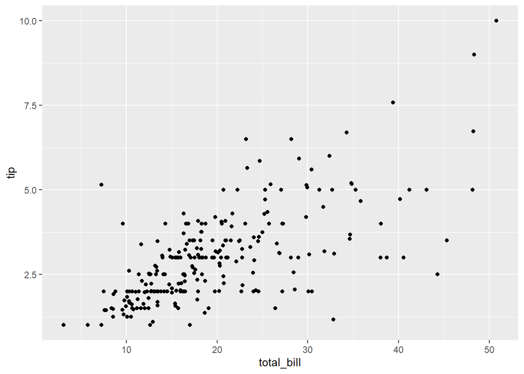

```r
#Problem 5
library(ggplot2)
ggplot(data=tips2,aes(x=total_bill,y=tip))+geom_point()
```

## Problem 5

You can see a clear pattern between total bill and the tip. As the total bill goes up, the variability of the tip also increases. In general there is a positive, linear trend in the data.

## Problem 6

There are a couple outliers in the data. There was one tip that was 5 dollars when the bill was under 10, but also one that was virtually zero with a bill over 30 dollars. These simply show that there is wide variability in the tip amount, even with a high bill total.

```r
#Problem 7
tips2$tiprate <- tips2$tip/tips2$total_bill
mean(tips2$tiprate)
```

```
## [1] 0.1608026
```

## Problem 7

The mean value of this new variable is 0.161. This means that the average tip percentage is 16.1 percent of the total bill.

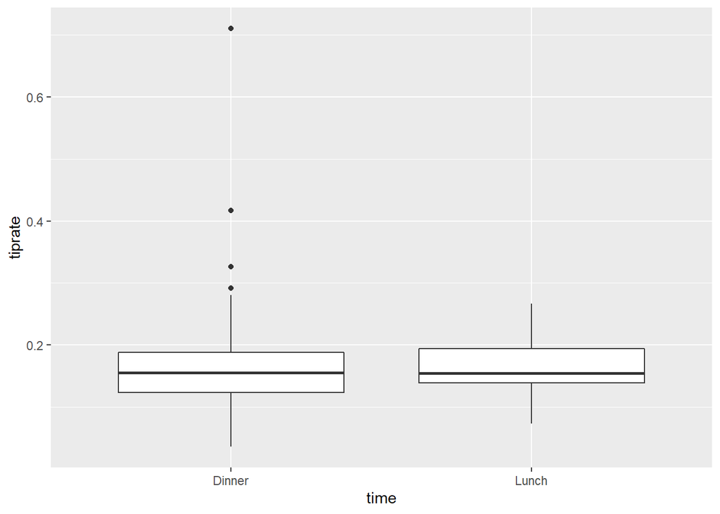

```r
#Problem 8
ggplot(data=tips2,aes(x=time,y=tiprate))+geom_boxplot()
```

## Problem 8

The boxplot reveals that tip rates have much more variability at dinner as opposed to lunch. Both means appear similar, but dinner had many more outliers towards the top, while also seeing some zeroes included.

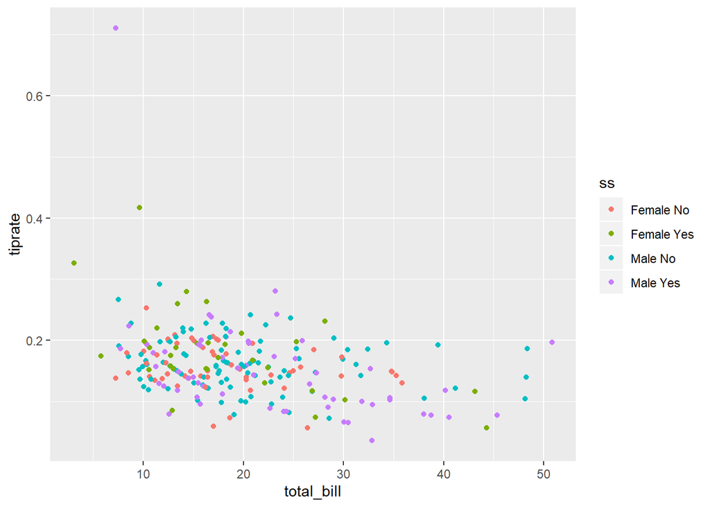

```r
#Problem 9
tips2$ss <- paste(tips2$sex,tips2$smoker)
qplot(total_bill,tiprate,data=tips2,color=ss)
```

# Problem 9

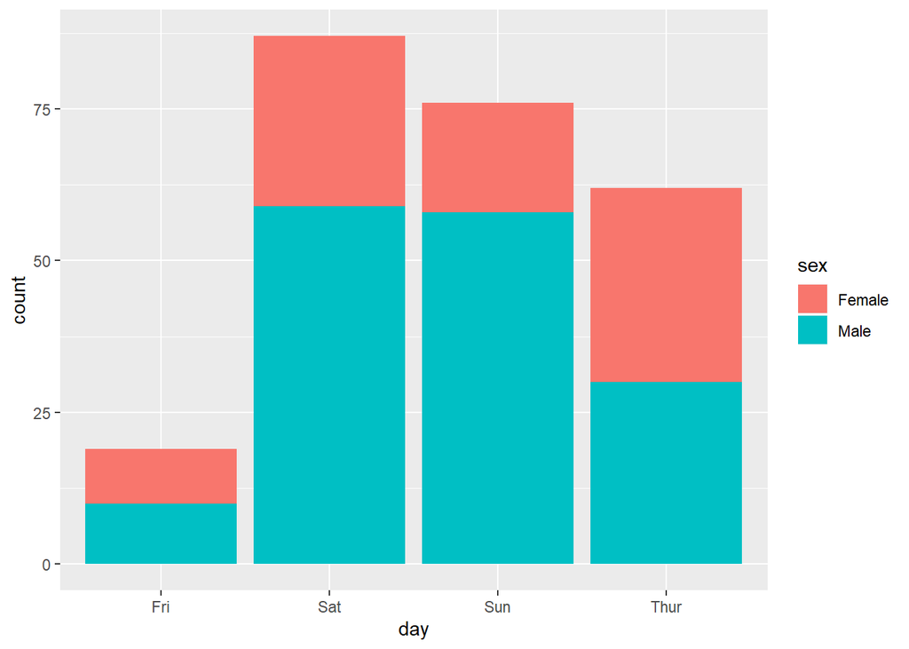

```r
#Problem 10
ggplot(data=tips2,aes(x=day,fill=sex))+geom_bar()
```

## Problem 10

Above is the plot. You can see that it’s roughly split between the sexes on Thursday and Friday, but the weekend provides mostly males as the billpayer.